# Practical Machine Learning Prediction Assignment

Ozge Tugrul Sonmez

December, 18, 2018

### Background

Using devices such as Jawbone Up, Nike FuelBand, and Fitbit it is now possible to collect a large amount of data about personal activity relatively inexpensively. These type of devices are part of the quantified self movement – a group of enthusiasts who take measurements about themselves regularly to improve their health, to find patterns in their behavior, or because they are tech geeks. One thing that people regularly do is quantify how much of a particular activity they do, but they rarely quantify how well they do it. In this project, your goal will be to use data from accelerometers on the belt, forearm, arm, and dumbell of 6 participants. They were asked to perform barbell lifts correctly and incorrectly in 5 different ways. More information is available from the website here: http://groupware.les.inf.puc-rio.br/har (see the section on the Weight Lifting Exercise Dataset).

### 1- Definition of the Goal of the Project

The goal of this project is to find out and quantify how well people do their physical activities, using data from acceleometers on the belt,forearm,arm and dumbell of 6 participants.

The training data https://d396qusza40orc.cloudfront.net/predmachlearn/pml-training.csv is partitioned for training and testing data for comparison of out of sample errors in different machine learning models.

The testing data https://d396qusza40orc.cloudfront.net/predmachlearn/pml-testing.csv is used for validation of the final machine learning classification model.

### 2- Data Preprocessing

First of all, csv files are read. It can be seen from the data, that some of the variables are null. So, null values are replaced with NA’s for the further operations on the data.

```r
setwd("C:/Users/asus/Desktop/Practical Machine Learning/Course project")

pml_training<-read.csv("pml-training.csv",header=TRUE,na.strings=c("","NA"))

pml_testing<-read.csv("pml-testing.csv",header=TRUE,na.strings=c("","NA"))

dim(pml_training)
```

```
## [1] 19622   160
```

```r
dim(pml_testing)
```

```
## [1]  20 160
```

**Data Preparation**

Decide which variables are going to be used in machine learning model. Remove the variables which include NA.

```r
ok_train<-complete.cases(t(pml_training))

pml_training<-pml_training[,ok_train]

ok_test<-complete.cases(t(pml_testing))

pml_testing<-pml_testing[,ok_test]

dim(pml_training)
```

```
## [1] 19622    60
```

```r
dim(pml_testing)
```

```
## [1] 20 60
```

Since the first five variables are identification variables and these are unrelevant to the dependent class variable, these variables are removed from the data.

```r
pml_training<-pml_training[,-c(1:5)]

pml_testing<-pml_testing[,-c(1:5)]

dim(pml_training)
```

```
## [1] 19622    55
```

```r
dim(pml_testing)
```

```
## [1] 20 55
```

### 3- Data Sliding

**Split the Data into Training and Test Set**

Divide the pml_training data into training and testing data in order to compare model accuracies.

```r
library(ggplot2)
library(caret)
set.seed(1111)

inTrain = createDataPartition(pml_training$classe, p=0.7,list=FALSE)
training = pml_training[inTrain,]
testing = pml_training[-inTrain,]

dim(training)
```

```
## [1] 13737    55
```

```r
dim(testing)
```

```
## [1] 5885   55
```

### 4- Machine Learning Models and Predictions

#### 4.1 Predicting with Trees

**Predicting with Trees using train() function**

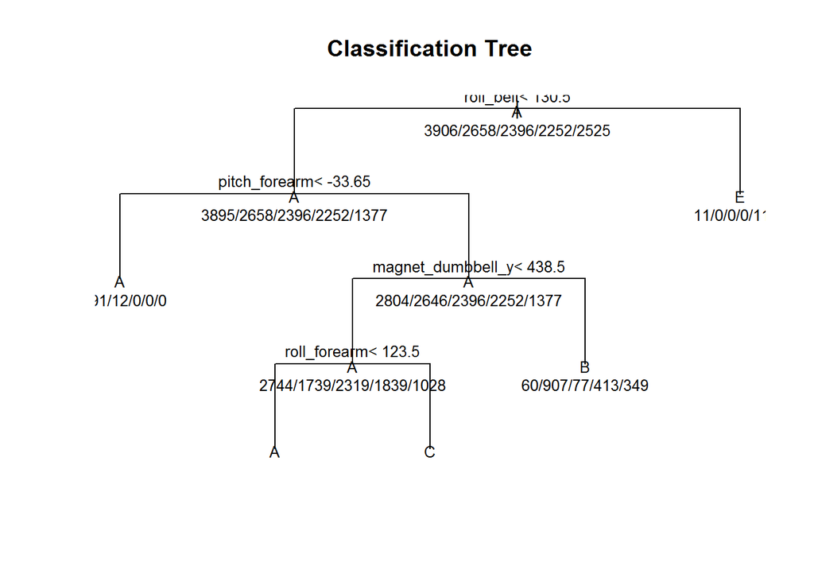

```r
ctrl<- trainControl(method='cv', number = 5)

rpart_train_model<-train(classe~.,data=training,method="rpart",trControl = ctrl)

plot(rpart_train_model$finalModel,uniform=TRUE,main="Classification Tree")
text(rpart_train_model$finalModel,use.n = TRUE,all=TRUE,cex=0.8)
```

```r
rpart_train_model_pred<-predict(rpart_train_model,testing)

confusionMatrix(rpart_train_model_pred,testing$classe)
```

```
## Confusion Matrix and Statistics
##
##           Reference
## Prediction    A    B    C    D    E
##          A 1524  478  458  447  162
##          B   27  386   32  159  141
##          C  120  275  536  358  296
##          D    0    0    0    0    0
##          E    3    0    0    0  483
##
## Overall Statistics
##
##                Accuracy : 0.4977
##                  95% CI : (0.4849, 0.5106)
##     No Information Rate : 0.2845
##     P-Value [Acc > NIR] : < 2.2e-16
##
##                   Kappa : 0.3434
##  Mcnemar's Test P-Value : NA
##
## Statistics by Class:
##
##                      Class: A Class: B Class: C Class: D Class: E
## Sensitivity            0.9104  0.33889  0.52242   0.0000  0.44640
## Specificity            0.6331  0.92436  0.78411   1.0000  0.99938
## Pos Pred Value         0.4966  0.51812  0.33817      NaN  0.99383
## Neg Pred Value         0.9467  0.85350  0.88605   0.8362  0.88905
## Prevalence             0.2845  0.19354  0.17434   0.1638  0.18386
## Detection Rate         0.2590  0.06559  0.09108   0.0000  0.08207
## Detection Prevalence   0.5215  0.12659  0.26933   0.0000  0.08258
## Balanced Accuracy      0.7717  0.63163  0.65326   0.5000  0.72289
```

**Predicting with Trees using tree() function**

```r
library(tree)

tree_model<-tree(classe~.,data=training)
tree_model_pred<-predict(tree_model,testing,type="class")

confusionMatrix(tree_model_pred,testing$classe)
```

```
## Confusion Matrix and Statistics
##
##           Reference
## Prediction    A    B    C    D    E
##          A 1452  104    0    4   21
##          B   44  682   59   83   84
##          C   28   54  833  252   88
##          D  131  257  126  617  230
##          E   19   42    8    8  659
##
## Overall Statistics
##
##                Accuracy : 0.721
##                  95% CI : (0.7093, 0.7324)
##     No Information Rate : 0.2845
##     P-Value [Acc > NIR] : < 2.2e-16
##
##                   Kappa : 0.6487
##  Mcnemar's Test P-Value : < 2.2e-16
##
## Statistics by Class:
##
##                      Class: A Class: B Class: C Class: D Class: E
## Sensitivity            0.8674   0.5988   0.8119   0.6400   0.6091
## Specificity            0.9694   0.9431   0.9132   0.8488   0.9840
## Pos Pred Value         0.9184   0.7164   0.6637   0.4533   0.8954
## Neg Pred Value         0.9484   0.9074   0.9583   0.9233   0.9178
## Prevalence             0.2845   0.1935   0.1743   0.1638   0.1839
## Detection Rate         0.2467   0.1159   0.1415   0.1048   0.1120
## Detection Prevalence   0.2686   0.1618   0.2133   0.2313   0.1251
## Balanced Accuracy      0.9184   0.7709   0.8625   0.7444   0.7965
```

**Predicting with Trees using rpart() function**

```r
library(rpart)

rpart_model<-rpart(classe~.,data=training,method="class")

rpart_model_pred<-predict(rpart_model,testing,type="class")

confusionMatrix(rpart_model_pred,testing$classe)
```

```
## Confusion Matrix and Statistics
##
##           Reference
## Prediction    A    B    C    D    E
##          A 1566  289   48  103   78
##          B   35  640  103   40   94
##          C   19   91  770   90   56
##          D   47   64   64  620   64
##          E    7   55   41  111  790
##
## Overall Statistics
##
##                Accuracy : 0.7453
##                  95% CI : (0.7339, 0.7564)
##     No Information Rate : 0.2845
##     P-Value [Acc > NIR] : < 2.2e-16
##
##                   Kappa : 0.6749
##  Mcnemar's Test P-Value : < 2.2e-16
##
## Statistics by Class:
##
##                      Class: A Class: B Class: C Class: D Class: E
## Sensitivity            0.9355   0.5619   0.7505   0.6432   0.7301
## Specificity            0.8770   0.9427   0.9473   0.9514   0.9554
## Pos Pred Value         0.7514   0.7018   0.7505   0.7218   0.7869
## Neg Pred Value         0.9716   0.8997   0.9473   0.9316   0.9402
## Prevalence             0.2845   0.1935   0.1743   0.1638   0.1839
## Detection Rate         0.2661   0.1088   0.1308   0.1054   0.1342
## Detection Prevalence   0.3541   0.1550   0.1743   0.1460   0.1706
## Balanced Accuracy      0.9062   0.7523   0.8489   0.7973   0.8428
```

#### 4.2 Predicting with Random Forest

**Predicting with Random Forest using train() function**

```r
ctrl<- trainControl(method='cv', number = 5)
rf_train_model<-train(classe~.,data=training,method="rf",trControl = ctrl)

rf_train_model_pred<-predict(rf_train_model,testing)

confusionMatrix(rf_train_model_pred,testing$classe)
```

```
## Confusion Matrix and Statistics
##
##           Reference
## Prediction    A    B    C    D    E
##          A 1673    3    0    0    0
##          B    1 1134    2    0    0
##          C    0    1 1024    3    0
##          D    0    1    0  961    2
##          E    0    0    0    0 1080
##
## Overall Statistics
##
##                Accuracy : 0.9978
##                  95% CI : (0.9962, 0.9988)
##     No Information Rate : 0.2845
##     P-Value [Acc > NIR] : < 2.2e-16
##
##                   Kappa : 0.9972
##  Mcnemar's Test P-Value : NA
##
## Statistics by Class:
##
##                      Class: A Class: B Class: C Class: D Class: E
## Sensitivity            0.9994   0.9956   0.9981   0.9969   0.9982
## Specificity            0.9993   0.9994   0.9992   0.9994   1.0000
## Pos Pred Value         0.9982   0.9974   0.9961   0.9969   1.0000
## Neg Pred Value         0.9998   0.9989   0.9996   0.9994   0.9996
## Prevalence             0.2845   0.1935   0.1743   0.1638   0.1839
## Detection Rate         0.2843   0.1927   0.1740   0.1633   0.1835
## Detection Prevalence   0.2848   0.1932   0.1747   0.1638   0.1835
## Balanced Accuracy      0.9993   0.9975   0.9986   0.9981   0.9991
```

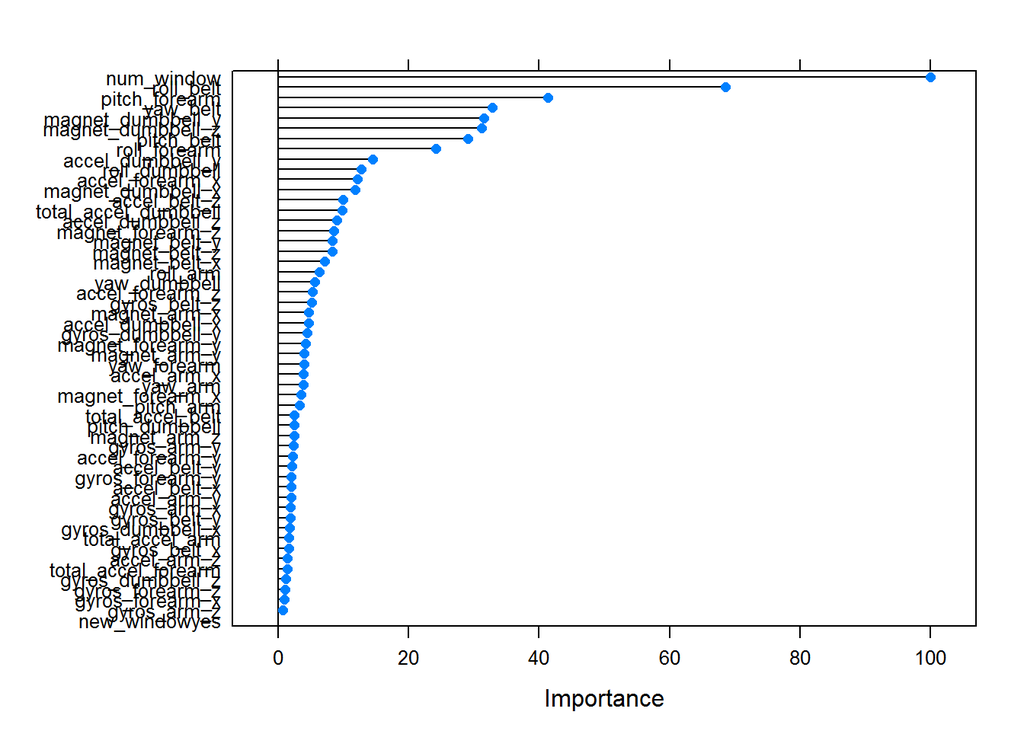

```r
plot(varImp(rf_train_model))
```

**Predicting with Random Forest using randomForest() function**

```r
library(randomForest)
rf_model<-randomForest(classe~.,data=training,importance=TRUE)
rf_model_pred<-predict(rf_model,testing)

confusionMatrix(rf_model_pred,testing$classe)
```

```
## Confusion Matrix and Statistics
##
##           Reference
## Prediction    A    B    C    D    E
##          A 1674    2    0    0    0
##          B    0 1135    4    0    0
##          C    0    2 1022    5    0
##          D    0    0    0  959    2
##          E    0    0    0    0 1080
##
## Overall Statistics
##
##                Accuracy : 0.9975
##                  95% CI : (0.9958, 0.9986)
##     No Information Rate : 0.2845
##     P-Value [Acc > NIR] : < 2.2e-16
##
##                   Kappa : 0.9968
##  Mcnemar's Test P-Value : NA
##
## Statistics by Class:
##
##                      Class: A Class: B Class: C Class: D Class: E
## Sensitivity            1.0000   0.9965   0.9961   0.9948   0.9982
## Specificity            0.9995   0.9992   0.9986   0.9996   1.0000
## Pos Pred Value         0.9988   0.9965   0.9932   0.9979   1.0000
## Neg Pred Value         1.0000   0.9992   0.9992   0.9990   0.9996
## Prevalence             0.2845   0.1935   0.1743   0.1638   0.1839
## Detection Rate         0.2845   0.1929   0.1737   0.1630   0.1835
## Detection Prevalence   0.2848   0.1935   0.1749   0.1633   0.1835
## Balanced Accuracy      0.9998   0.9978   0.9973   0.9972   0.9991
```

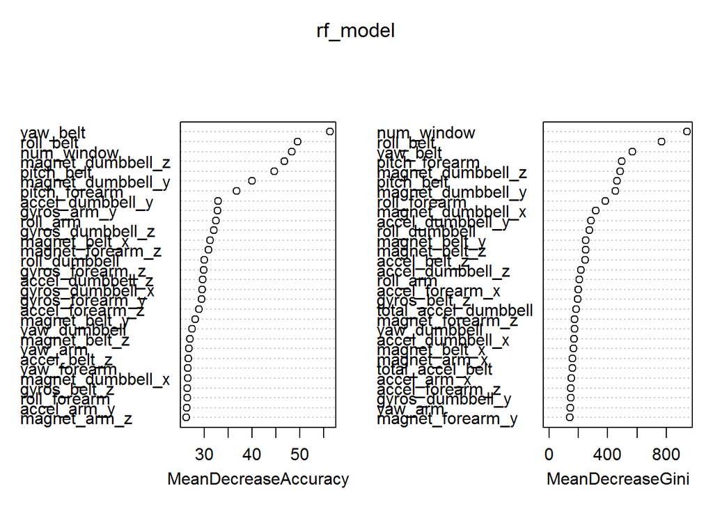

```r
varImpPlot(rf_model)
```

#### 4.3 Predicting with Generalized Boosted Model using train() function

```r
library(gbm)
ctrl<- trainControl(method='cv', number = 5)

boost_train_model<-train(classe~.,method="gbm",data=training,trControl = ctrl,verbose=FALSE)

boost_train_model_pred<-predict(boost_train_model,testing)

confusionMatrix(boost_train_model_pred,testing$classe)
```

```
## Confusion Matrix and Statistics
##
##           Reference
## Prediction    A    B    C    D    E
##          A 1666   11    0    0    0
##          B    6 1115   13    1    1
##          C    0   12 1011   10    0
##          D    2    0    2  953    7
##          E    0    1    0    0 1074
##
## Overall Statistics
##
##                Accuracy : 0.9888
##                  95% CI : (0.9858, 0.9913)
##     No Information Rate : 0.2845
##     P-Value [Acc > NIR] : < 2.2e-16
##
##                   Kappa : 0.9858
##  Mcnemar's Test P-Value : NA
##
## Statistics by Class:
##
##                      Class: A Class: B Class: C Class: D Class: E
## Sensitivity            0.9952   0.9789   0.9854   0.9886   0.9926
## Specificity            0.9974   0.9956   0.9955   0.9978   0.9998
## Pos Pred Value         0.9934   0.9815   0.9787   0.9886   0.9991
## Neg Pred Value         0.9981   0.9949   0.9969   0.9978   0.9983
## Prevalence             0.2845   0.1935   0.1743   0.1638   0.1839
## Detection Rate         0.2831   0.1895   0.1718   0.1619   0.1825
## Detection Prevalence   0.2850   0.1930   0.1755   0.1638   0.1827
## Balanced Accuracy      0.9963   0.9873   0.9904   0.9932   0.9962
```

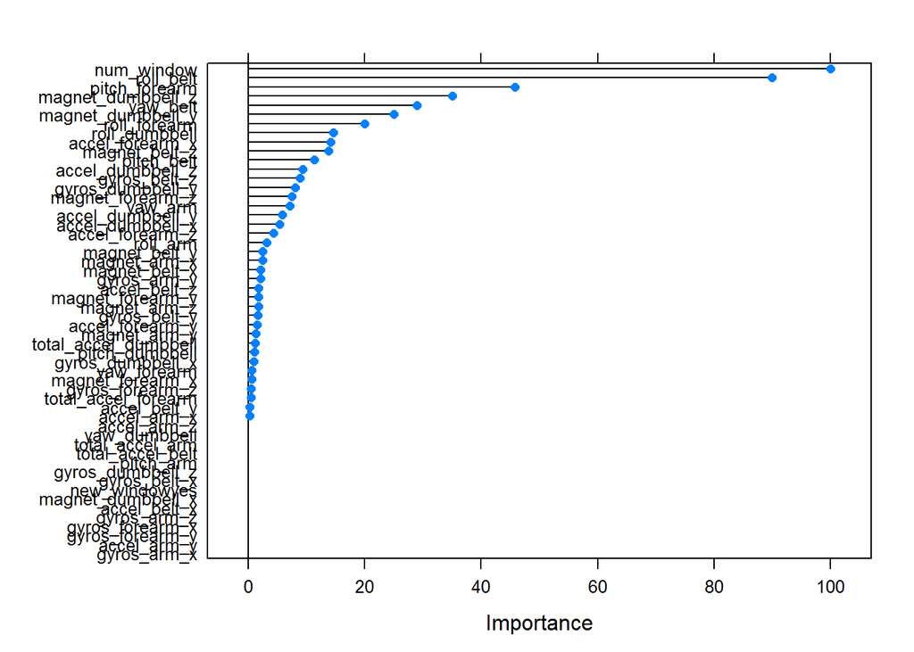

```r
plot(varImp(boost_train_model))
```

### 5- Final Model

Since, the accuracy of the Random Forest prediction using train() function is higher than other models’ accuracy on testing data, **rf_train_model** is chosen for predicting the **pml_testing** data.

```r
c<-confusionMatrix(rf_train_model_pred,testing$classe)
final_model_accuracy<-c$overall[1]
final_model_accuracy
```

```
## Accuracy
## 0.997791
```

### 6- Evaluation of the Final Model Prediction Accuracy with Test Data.

For each of the 20 observations in the **pml_testing** data, which are given for completing the Week 4 Practical Machine Learning Assignment Quiz, Final Model’s (rf_train_model) prediction results are given below:

```r
predict(rf_train_model,pml_testing)
```

```
##  [1] B A B A A E D B A A B C B A E E A B B B
## Levels: A B C D E
```